# NYPD Shooting Incidents

Ola Klingberg

2023-06-13

# Sources of data

### NYPD shootings data

https://catalog.data.gov/dataset/nypd-shooting-incident-data-historic

### Census data

##### 2010

https://data.census.gov/table?g=040XX00US36_050XX00US36005,36047,36061,36081,36085&y=2010&d=DEC+Redistricting+Data+(PL+94-171)

##### 2020

https://data.census.gov/table?g=040XX00US36_050XX00US36005,36047,36061,36081,36085&y=2020&d=DEC+Redistricting+Data+(PL+94-171)

# R Libraries

```r
library(tidyverse)
library(lubridate)
library(janitor)
```

# Import and tidy up the data

### NYPD shooting data

```r
## Import the data.
url <- "https://data.cityofnewyork.us/api/views/833y-fsy8/rows.csv?accessType=DOWNLOAD"
shootings_raw <- read_csv(url)

# Clean up column names.
shootings <- clean_names(shootings_raw)

# Select the variables that might be used in this study.
shootings <- shootings %>%
  select(c(occur_date, occur_time, boro, perp_age_group, perp_race,
           perp_sex, vic_age_group, vic_race, vic_sex))

# Turn the date into a date object.
shootings <- shootings %>%
  mutate(occur_date = mdy(occur_date))

# Turn relevant character values into factors
shootings$boro <- as.factor(shootings$boro)
shootings$vic_age_group <- as.factor(shootings$vic_age_group)
shootings$vic_race <- as.factor(shootings$vic_race)
shootings$vic_sex <- as.factor(shootings$vic_sex)
shootings$perp_age_group <- as.factor(shootings$perp_age_group)
shootings$perp_race <- as.factor(shootings$perp_race)
shootings$perp_sex <- as.factor(shootings$perp_sex)
```

### NYPD shooting data summary

```r
summary(shootings)
```

```
##    occur_date          occur_time                  boro       perp_age_group
##  Min.   :2006-01-01   Length:28562      BRONX        : 8376   18-24  :6438
##  1st Qu.:2009-09-04   Class1:hms        BROOKLYN     :11346   25-44  :6041
##  Median :2013-09-20   Class2:difftime   MANHATTAN    : 3762   UNKNOWN:3148
##  Mean   :2014-06-07   Mode  :numeric    QUEENS       : 4271   <18    :1682
##  3rd Qu.:2019-09-29                     STATEN ISLAND:  807   (null) :1141
##  Max.   :2023-12-29                                           (Other): 768
##                                                               NA's   :9344
##           perp_race       perp_sex     vic_age_group
##  BLACK         :11903   (null): 1141   <18    : 2954
##  WHITE HISPANIC: 2510   F     :  444   1022   :    1
##  UNKNOWN       : 1837   M     :16168   18-24  :10384
##  BLACK HISPANIC: 1392   U     : 1499   25-44  :12973
##  (null)        : 1141   NA's  : 9310   45-64  : 1981
##  (Other)       :  469                  65+    :  205
##  NA's          : 9310                  UNKNOWN:   64
##                            vic_race     vic_sex
##  AMERICAN INDIAN/ALASKAN NATIVE:   11   F: 2760
##  ASIAN / PACIFIC ISLANDER      :  440   M:25790
##  BLACK                         :20235   U:   12
##  BLACK HISPANIC                : 2795
##  UNKNOWN                       :   70
##  WHITE                         :  728
##  WHITE HISPANIC                : 4283
```

As can be seen above, there are no missing values in the columns for:

- date of incident (occur_date)
- time of incident (occur_time)
- the boro where the incident took place (boro)
- the age group of the victim (vic_age_group)
- the race of the victim (vic_race)
- the sex of the victim (vic_sex)

Values are missing in roughly a third of the rows for:

- the age group of the perpetrator (perp_age_group)
- the race of the perpetrator (perp_race)
- the sex of the perpetrator (perp_sex)

These variables will not be used in the initial analysis. If they are used in later analyses, a decision will have be taken about how to handle this large number of missing values.

### Census data

This data will be used later in the analysis to calculate shooting incidents per million inhabitants in each boro.

```r
# Import the data.
census_2010 <- read_csv("./Data/2010_census_data.csv")
census_2020 <- read_csv("./Data/2020_census_data.csv")

# Clean up the column names.
census_2010 <- clean_names(census_2010)
census_2020 <- clean_names(census_2020)

# Rename the columns with the boro names instead of the county names.
# The col new_york contains state-wide numbers, so rename it new_york_state.
census_2010 <- census_2010 %>%
  rename(new_york_state = new_york,
         bronx = bronx_county_new_york,
         brooklyn = kings_county_new_york,
         queens = queens_county_new_york,
         manhattan = new_york_county_new_york,
         staten_island = richmond_county_new_york)

census_2020 <- census_2020 %>%
  rename(new_york_state = new_york,
         bronx = bronx_county_new_york,
         brooklyn = kings_county_new_york,
         queens = queens_county_new_york,
         manhattan = new_york_county_new_york,
         staten_island = richmond_county_new_york)
```

# Historical trend

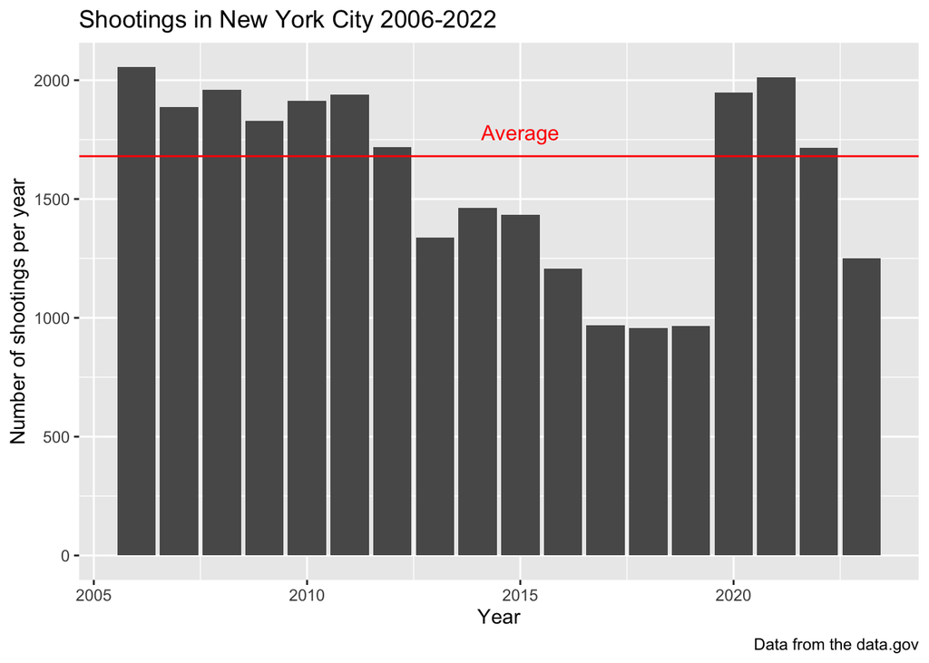

```r
# By year
shootings %>%
  ggplot(aes(x = year(occur_date))) +
  geom_bar() +
  # Divide the total numbers of shootings by 17 to get the yearly average.
  geom_hline(yintercept = nrow(shootings) / 17, color = "red") +
  annotate("text",
           x = 2015,
           y = (nrow(shootings) / 17) + 100, label = "Average", color = "red", size = 4) +
  labs(title = "Shootings in New York City 2006-2022",
       caption = "Data from the data.gov") +
  xlab("Year") +
  ylab("Number of shootings per year")
```

As can be seen in the chart, there was a significant and fairly steady decline in the number of shootings starting in 2012 and lasting through 2017. The numbers then stayed level through 2019, the last year before the pandemic hit New York. The first two years of the pandemic, 2020 and 2021, saw a return to levels similar to those of 2011, i.e. before the decline started. For 2022, there is a significant drop in the numbers, but they still remain far above the numbers for 2017–2019.

This finding agrees well with the much-publicized increase in violent crime since the beginning of the pandemic. It would be interesting to investigate further how the numbers for different types of shooting incidents changed: domestic violence, robberies, etc. The current data set on its own does not seem to allow for such a study.

# Shootings by hour of the day

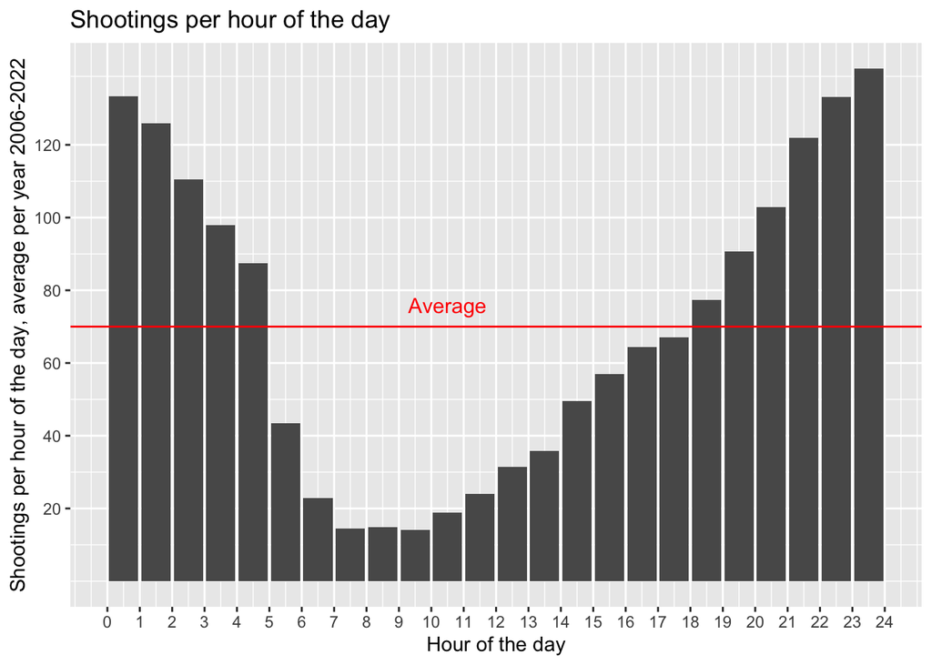

```r
# By hour of the day
shootings %>%
  ggplot(aes(x = hour(occur_time))) +
  geom_bar() +
  # Divide the total number of shootings by 24 to get the hourly average.
  geom_hline(yintercept = nrow(shootings) / 24, color = "red") +
  annotate("text",
           x = 10,
           y = (nrow(shootings) / 24) + 100, label = "Average", color = "red", size = 4) +
  xlab("Hour of the day") +
  ylab("Shootings per hour of the day, average per year 2006-2022") +
  labs(title = "Shootings per hour of the day") +
  scale_x_continuous(breaks = c(-.5:23.5),
                     labels = c(0:24)) +
  # Divide the label numbers by 17, to get numbers per year.
  scale_y_continuous(breaks = c(340, 680, 1020, 1360, 1700, 2040, 2680),
                     labels = c(20, 40, 60, 80, 100, 120, 140))
```

As can be seen in the graph, shootings are mainly a night-time phenomenon, with the number of shootings between 11 PM and midnight being roughly ten times the number per hour between 7 AM and 10 AM.

# Shootings per month of the year

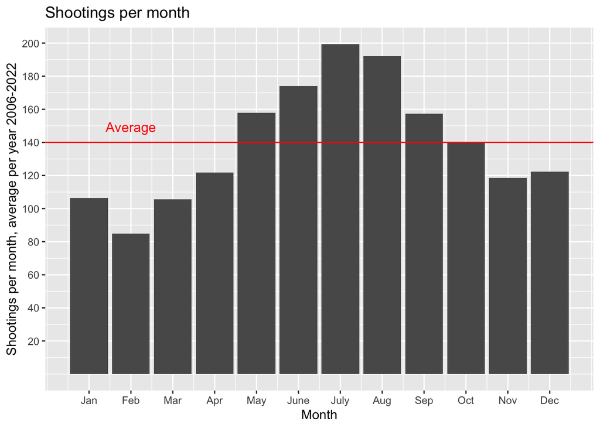

```r
# By month of the year
shootings %>%
  ggplot(aes(x = month(occur_date))) +
  geom_bar() +
  geom_hline(yintercept = nrow(shootings) / 12, color = "red") +
  annotate("text",
           x = 2,
           y = (nrow(shootings) / 12) + 160, label = "Average", color = "red", size = 4) +
  labs(title = "Shootings per month") +
  xlab("Month") +
  ylab("Shootings per month, average per year 2006-2022") +
  scale_x_continuous(breaks = c(1:12),
                     labels = c("Jan", "Feb", "Mar", "Apr", "May", "June",
                              "July", "Aug", "Sep", "Oct", "Nov", "Dec")) +
  scale_y_continuous(breaks = c(340, 680, 1020, 1360, 1700, 2040, 2380, 2720,
                                3060, 3400),
                     labels = c(20, 40, 60, 80, 100, 120, 140, 160, 180, 200))
```

The graph shows us that shootings are more common in the summer. The average number of shootings in July is more than twice as high as the average number for February.

Let’s see if this pattern holds true for the two years immediately preceding the pandemic (2018, 2019), as well as for the first two years of the pandemic (2020, 2021).

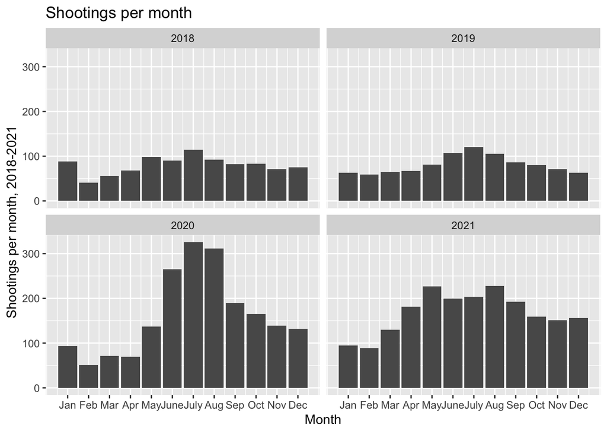

```r
# By month of the year, for the years 2018--2022
shootings %>%
  filter(year(occur_date) >= 2018 & year(occur_date) <= 2021) %>%
  ggplot(aes(x = month(occur_date))) +
  geom_bar() +
  facet_wrap(~year(occur_date)) +
  labs(title = "Shootings per month") +
  xlab("Month") +
  ylab("Shootings per month, 2018-2021") +
  scale_x_continuous(breaks = c(1:12),
                     labels = c("Jan", "Feb", "Mar", "Apr", "May", "June",
                              "July", "Aug", "Sep", "Oct", "Nov", "Dec"))
```

It’s also interesting to note that the sharp increase in numbers in 2020 is not perfectly correlated with the beginning of the COVID lockdown in New York (which began around March 17, 2020). Rather, the numbers for April 2020 look similar to those for April 2018 and April 2019. In May 2020, we see a sharp increase compared with the same month in 2018 and 2019, but the most significant difference from 2018 and 2019 doesn’t show up until the summer months: June, July, and August 2020 have close to three times as many shootings as the same months in 2018 and 2019.

## A closer look at the time around the beginning of the pandemic

```r
#
shootings_per_day_2019_03_17__2019_04_30 =
  nrow(shootings[shootings$occur_date >= '2019-03-17' &
                   shootings$occur_date <= '2019-04-30',]) / 45

#
shootings_per_day_2019_05_01__2019_05_31 =
  nrow(shootings[shootings$occur_date >= '2019-05-01' &
                   shootings$occur_date <= '2019-05-31',]) / 31

#
shootings_per_day_2019_06_01__2019_08_31 =
  nrow(shootings[shootings$occur_date >= '2019-06-01' &
                   shootings$occur_date <= '2019-08-31',]) / 92

#
shootings_per_day_2020_03_17__2020_04_30 =
  nrow(shootings[shootings$occur_date >= '2020-03-17' &
                   shootings$occur_date <= '2020-04-30',]) / 45

#
shootings_per_day_2020_05_01__2020_05_31 =
  nrow(shootings[shootings$occur_date >= '2020-05-01' &
                   shootings$occur_date <= '2020-05-31',]) / 31

#
shootings_per_day_2020_06_01__2020_08_31 =
  nrow(shootings[shootings$occur_date >= '2020-06-01' &
                   shootings$occur_date <= '2020-08-31',]) / 92

# Average number of daily shootings from beginning of lockdown 2020-03-17
# till end of April,
# compared with the same period in 2019.
shootings_per_day_2020_03_17__2020_04_30 / shootings_per_day_2019_03_17__2019_04_30
```

```
## [1] 0.961165
```

```r
# May 2020 compared with May 2019.
shootings_per_day_2020_05_01__2020_05_31 / shootings_per_day_2019_05_01__2019_05_31
```

```
## [1] 1.691358
```

```r
# June, July, and August 2020 compared with the same
shootings_per_day_2020_06_01__2020_08_31 / shootings_per_day_2019_06_01__2019_08_31
```

```
## [1] 2.713855
```

We see that the first month and a half after the start of the lockdown in New York City (2020-03-17 – 2020-04-30) actually had a slightly lower number of daily shootings than the same period in 2019. May 2020 had 1.69 times as many daily shootings as May 2019, and the summer months (June, July, August) of 2020 had a stunning 2.71 times as many daily shootings as the same period in 2019.

# Shootings by borough

Let’s now look at the number of shootings broken down by borough. The boroughs have very different populations, ranging from less than half a million in Staten Island to over 2.7 million in Brooklyn. We will look at shootings per million inhabitants and year in each of the five boroughs, as well as in New York City as a whole.

We will look at the years 2010 and 2020, since we have census data from those years. We will also look at 2019, since it may be interesting to compare 2019 (the last year before the pandemic) with 2020 (the first year of the pandemic). To estimate population numbers for 2019, we will use a linear interpolation between the census numbers for 2010 and 2020.

### Total number of shootings by borough for 2010, 2019, and 2020

```r
# Shootings 2010
shootings_by_boro_2010 <-shootings %>%
  filter(year(occur_date) == 2010) %>%
  select(boro) %>%
  table() %>%
  transform() %>%
  rename(shootings_2010 = Freq)

# Shootings 2019
shootings_by_boro_2019 <-shootings %>%
  filter(year(occur_date) == 2019) %>%
  select(boro) %>%
  table() %>%
  transform() %>%
  rename(shootings_2019 = Freq)

# Shootings 2020
shootings_by_boro_2020 <-shootings %>%
  filter(year(occur_date) == 2020) %>%
  select(boro) %>%
  table() %>%
  transform() %>%
  rename(shootings_2020 = Freq)

# Merge shootings for 2010, 2019, and 2020 into one data frame.
summary_by_boro <- merge(shootings_by_boro_2010,
                         shootings_by_boro_2019,
                         by = "boro")
summary_by_boro <- merge(summary_by_boro,
                         shootings_by_boro_2020,
                         by = "boro")

# Write the boros with only the initial letter of each word capitalized.
summary_by_boro$boro <- summary_by_boro$boro %>% str_to_title()

summary_by_boro
```

```
##            boro shootings_2010 shootings_2019 shootings_2020
## 1         Bronx            525            267            504
## 2      Brooklyn            805            372            819
## 3     Manhattan            260            146            272
## 4        Queens            288            156            303
## 5 Staten Island             34             26             50
```

### Population numbers for 2010, 2019, and 2020

```r
# 2010
summary_by_boro <- summary_by_boro %>%
  mutate(pop_2010 = c(census_2010$bronx[1],
                      census_2010$brooklyn[1],
                      census_2010$manhattan[1],
                      census_2010$queens[1],
                      census_2010$staten_island[1]))

# 2020
summary_by_boro <- summary_by_boro %>%
  mutate(pop_2020 = c(census_2020$bronx[1],
                      census_2020$brooklyn[1],
                      census_2020$manhattan[1],
                      census_2020$queens[1],
                      census_2020$staten_island[1]))

# Add a row for New York City, i.e. a summary of the five boros.
summary_by_boro <- summary_by_boro %>% adorn_totals("row")

# Turn the boros into row names
row.names(summary_by_boro) <- summary_by_boro$boro
summary_by_boro <- summary_by_boro %>% select(-boro)

# Add a col for 2019, and interpolate between 2010 and 2020.
summary_by_boro <- summary_by_boro %>%
  mutate(pop_2019 = round((summary_by_boro$pop_2010 + 9 * summary_by_boro$pop_2020) / 10))

# Add cols for shootings per million people
summary_by_boro <- summary_by_boro %>%
  mutate(shoot_per_mil_2010 = (shootings_2010 * 1000000) / pop_2010,
         shoot_per_mil_2019 = (shootings_2019 * 1000000) / pop_2019,
         shoot_per_mil_2020 = (shootings_2020 * 1000000) / pop_2020)

summary_by_boro
```

```
##  shootings_2010 shootings_2019 shootings_2020 pop_2010 pop_2020 pop_2019
##             525            267            504  1385108  1472654  1463899
##             805            372            819  2504700  2736074  2712937
##             260            146            272  1585873  1694251  1683413
##             288            156            303  2230722  2405464  2387990
##              34             26             50   468730   495747   493045
##            1912            967           1948  8175133  8804190  8741284
##  shoot_per_mil_2010 shoot_per_mil_2019 shoot_per_mil_2020
##           379.03182          182.38963           342.2392
##           321.39578          137.12077           299.3340
##           163.94755           86.72857           160.5429
##           129.10618           65.32691           125.9632
##            72.53643           52.73352           100.8579
##           233.87999          110.62448           221.2583
```

To enable an easy-to-read visualization of the data in summary_by_boro, we’ll build a new summary table, which contains the same data, but structured differently.

```r
boro <- c(rep("Bronx", 3), rep("Brooklyn", 3), rep("Manhattan", 3),
           rep("Queens", 3), rep("Staten Island", 3), rep("Total", 3))
year <- rep(c("2010", "2019", "2020"), 6)
shootings <- c(summary_by_boro["Bronx", "shootings_2010"],
               summary_by_boro["Bronx", "shootings_2019"],
               summary_by_boro["Bronx", "shootings_2020"],
               summary_by_boro["Brooklyn", "shootings_2010"],
               summary_by_boro["Brooklyn", "shootings_2019"],
               summary_by_boro["Brooklyn", "shootings_2020"],
               summary_by_boro["Manhattan", "shootings_2010"],
               summary_by_boro["Manhattan", "shootings_2019"],
               summary_by_boro["Manhattan", "shootings_2020"],
               summary_by_boro["Queens", "shootings_2010"],
               summary_by_boro["Queens", "shootings_2019"],
               summary_by_boro["Queens", "shootings_2020"],
               summary_by_boro["Staten Island", "shootings_2010"],
               summary_by_boro["Staten Island", "shootings_2019"],
               summary_by_boro["Staten Island", "shootings_2020"],
               summary_by_boro["Total", "shootings_2010"],
               summary_by_boro["Total", "shootings_2019"],
               summary_by_boro["Total", "shootings_2020"])
pop <- c(summary_by_boro["Bronx", "pop_2010"],
         summary_by_boro["Bronx", "pop_2019"],
         summary_by_boro["Bronx", "pop_2020"],
         summary_by_boro["Brooklyn", "pop_2010"],
         summary_by_boro["Brooklyn", "pop_2019"],
         summary_by_boro["Brooklyn", "pop_2020"],
         summary_by_boro["Manhattan", "pop_2010"],
         summary_by_boro["Manhattan", "pop_2019"],
         summary_by_boro["Manhattan", "pop_2020"],
         summary_by_boro["Queens", "pop_2010"],
         summary_by_boro["Queens", "pop_2019"],
         summary_by_boro["Queens", "pop_2020"],
         summary_by_boro["Staten Island", "pop_2010"],
         summary_by_boro["Staten Island", "pop_2019"],
         summary_by_boro["Staten Island", "pop_2020"],
         summary_by_boro["Total", "pop_2010"],
         summary_by_boro["Total", "pop_2019"],
         summary_by_boro["Total", "pop_2020"])

summary_by_boro_alt <- data.frame(boro, year, shootings, pop)

summary_by_boro_alt <- summary_by_boro_alt %>%
  mutate(shoot_per_mil = (shootings * 1000000) / pop)

summary_by_boro_alt
```

```
##             boro year shootings     pop shoot_per_mil
## 1          Bronx 2010       525 1385108     379.03182
## 2          Bronx 2019       267 1463899     182.38963
## 3          Bronx 2020       504 1472654     342.23925
## 4       Brooklyn 2010       805 2504700     321.39578
## 5       Brooklyn 2019       372 2712937     137.12077
## 6       Brooklyn 2020       819 2736074     299.33401
## 7      Manhattan 2010       260 1585873     163.94755
## 8      Manhattan 2019       146 1683413      86.72857
## 9      Manhattan 2020       272 1694251     160.54292
## 10        Queens 2010       288 2230722     129.10618
## 11        Queens 2019       156 2387990      65.32691
## 12        Queens 2020       303 2405464     125.96322
## 13 Staten Island 2010        34  468730      72.53643
## 14 Staten Island 2019        26  493045      52.73352
## 15 Staten Island 2020        50  495747     100.85790
## 16         Total 2010      1912 8175133     233.87999
## 17         Total 2019       967 8741284     110.62448
## 18         Total 2020      1948 8804190     221.25829
```

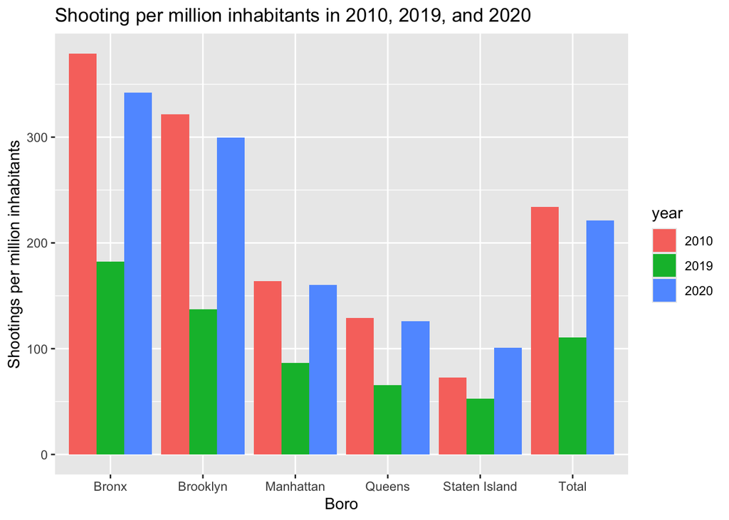

```r
# Visualize
summary_by_boro_alt %>%
  ggplot(aes(x = boro, y = shoot_per_mil, fill = year)) +
  geom_bar(position = "dodge", stat = "identity") +
  xlab("Boro") +
  ylab("Shootings per million inhabitants") +
  labs(title = "Shooting per million inhabitants in 2010, 2019, and 2020")
```

We see that for all three years, the Bronx is the borough with highest number of shooting incidents per million inhabitants, and Staten Island is the one with the lowest.

# Possible sources of bias

### NYPD data

Presumably, this data set only contains shootings known by the police. But in an urban setting like New York City, it seems likely that the great majority of shootings do come to the attention of the police.

Worth noting is also that the total numbers for Staten Island are rather small: e.g. in 2019, there were only 26 shootings. With such small numbers, chance can have a large impact.

Furthermore, Manhattan surely has a much larger number of visitors than the other boros (both visitors from other boros and visitors from outside the city). This means that on any given day, the number of people moving around in Manhattan is larger than the number of people living there, probably much larger, while the same is not true for the other boros. It might therefore be misleading to compare shooting numbers with the number of inhabitants in a boro.

### Census data

The U.S. Census is in general regarded as reliable, but there is a possibility of undocumented immigrants being underreported, and this could skew the population numbers.